[figure not shown]

Figure 1. Snapchat views per day as a function of Instagram views per day. Only data with at least some usage for both social media platforms was used. A direct correlation between Instagram usage and Snapchat usage exists. The data was further divided into two groups: those with a bae in the ecology class and those without. Those with a bae trended a higher snapchat usage comparitively. Perhaps, this is a result of those with a bae using Snapchat to take pictures of them during class.

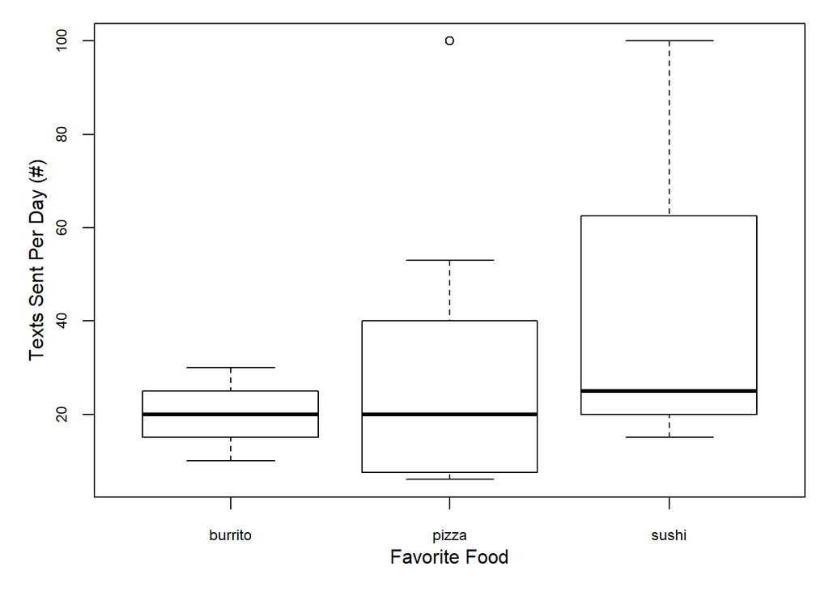

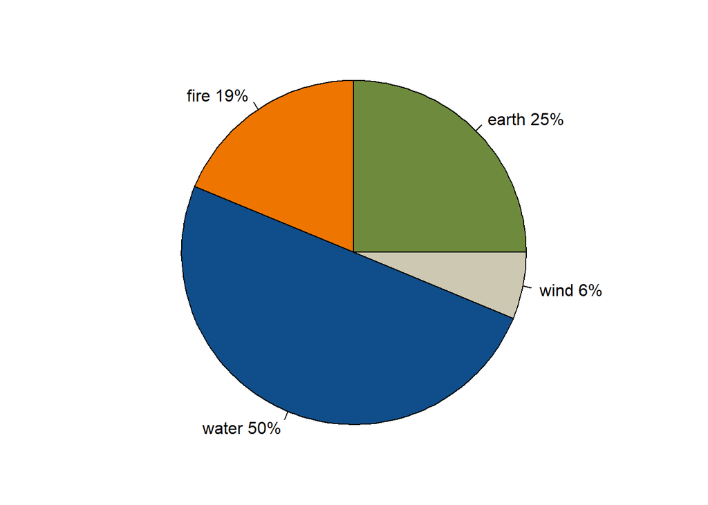

Figure 3. Pie chart of chosen *Captain Planet* power. 50% of the students surveyed (8/16) chose “water”, 25% (4/16) chose “earth”, 19% (3/16) chose “fire”, and 6% (1/16) chose “wind”. Though the small sample size may account for the large variation in power choices, it is likely that none of the students chose the “heart” power because STEM sudents are not allowed to have feelings.